# 2.05-Doubly-Linked-Lists

### Topics Covered

- Introduction
- Append
- Prepend
- Pop Left
- Pop Right
- Remove
- Table of Complexity Comparison - Array vs Singly Linked List vs Doubly Linked List
- Real-Life Applications of Singly Linked Lists

### Introduction to Doubly Linked List

Single Linked Lists design was perfectly fine for most operations, but it showed its weakness when we wanted to remove the last node, because at that point we needed to know what was the node right before the tail, which could not be accessed directly. So we needed to traverse the entire list starting from the head. This might not always be a huge issue, but for large lists or if we need to do this action, often we could have some performance issues

The solution for this was to modify the node objects themselves, instead of them holding only the value and a pointer to the next node. Why not also add a pointer to the previous node? And this is how the doubly linked list was born

A **Doubly Linked List** is composed of nodes that contain references to both the next node as well as the previous one

**Single Linked Lists**

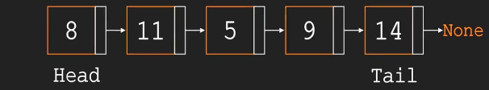

**Doubly Linked Lists**

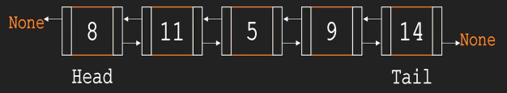

The only difference is that each node will have an additional property for the previous node. And that's pretty much all the theory behind it. Let's now go ahead and implement a doubly linked list

For us to transform our previous list into a doubly linked list, we only need to add one new attribute to the node class. So we will just copy and paste the two class definitions, including the constructor functions. And in the node class just add a new property called previous with an initial value of none and everything else inside it will stay the same. As you can see, the base structure of our doubly linked list is almost the same as the singly linked one, and the methods will also be very similar. We only need to adjust them to handle the new property. And that is it. Our setup is complete

```python
class Node: # Creating a Node and initializing it with 2 containers (a.Value  b.Pointing to next/previous node)
    def __init__(self, value):
        self.value = value # This will store the actual value
        self.next = None # this will store the pointer or points to next node it will be linking. For now its None (Node is empty)
        self.previous = None # this will store the pointer or points to previous node it will be linking.

class DoublyLinkedList: # Creating a new class to track first(head) and last(tail) element of the List
    def __init__(self): # These are attributes (sometimes called instance variables).They hold values for head, tail & length
        self.head = None # We don't want to give them any starting values.We want the list to be empty when initialized
        self.tail = None # Both the head and the tail will eventually be some node objects we just defined up (in Node Class)
        self._length = 0 # Initial value is set to 0, we will increase and decrease it as we add or remove nodes
# The length is not mandatory, but it will make our lives easier with certain methods.And generally the length of a list is a pretty useful thing to know
# We'll define our append method inside the Doubly linked list class, so that we can call it on an instance of this class
```

### Append

**Adding new Node**

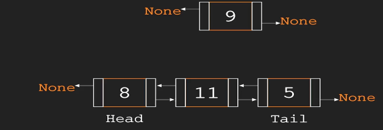

**Post Appending New Node**

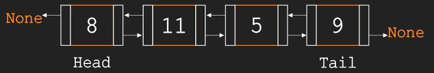

```python
def append(self, value): # It takes self (the current LinkedList object) and value (the data you want to add/append).
    new_node = Node(value) # Creates a new Node object with the given value.
    if not self._length: # Checks if the list is empty. "self._length" tracks how many nodes are in the list. If _length is 0, this condition is True
        self.head = self.tail = new_node # If the list is empty,the new node becomes both the head(first node)& the tail(last node).
    else :                               # This initializes the linked list with its first element.
        self.tail.next = new_node # If the list is not empty: links the current last node to the new node.
        new_node.previous = self.tail # link the back pointer to previous node to complete the handshake
        self.tail = new_node # updates the tail pointer so the new node is now the last node.
    self._length += 1 # Increases the length counter by 1 since a new node was added.
    return self # Returns the linked list object itself (self). This allows method chaining* (e.g., mylist.append(10).append(20)
```

We keep everything same as in Single Linked List and add a new line (new_node.previous) we make the tail point to the new node, which is correct, and then we make the new node a new tail. So we still want both of these lines in our new version of append. But we're missing one thing. And that is to make the new node point to the old tail. So before we update the tail, we want a new line that sets the previous property of the new node equal to the tail. And now we have that double connection we just talked about

```python
# Object assigned to class
my_list = DoublyLinkedList()
```

```python
# Python doesnt know what to display and all it displays is the memory location
print(my_list)
```

```
<__main__.DoublyLinkedList object at 0x000002018484EF00>
```

```python
# Lets look at the status of all 3 attributes when the node is empty
print(my_list.head)
print(my_list.head)
print(my_list._length)
```

```
None
None
0
```

```python
# Now lets start adding value
my_list.append(8)
my_list.append(11)
```

```
<__main__.DoublyLinkedList at 0x2018484ef00>
```

```python
# Lets also add using the method chaining
my_list.append(5).append(9)
```

```
<__main__.DoublyLinkedList at 0x2018484ef00>
```

```python
# Now lets review again the value of each attribute
print(my_list.head.value)
print(my_list.tail.value)
print(my_list._length)
```

```
8
9
4
```

#### Time And Space Complexity

In terms of time consumption. We only do constant time operations. We don't do any loops. We only have a certain number of variable assignments and a conditional check. Therefore the time complexity is O(1). The space complexity is also O(1). With every new invocation, we consume the same amount of memory the one needed to store our new node, regardless of how big our list would get. But none of this should be a surprise if you paid attention to the append method from the singly linked list. We basically have the same function except for line (new_node.previous). And that is all for the append method

##### Time : *O* (1)

##### Space : *O* (1)

### Prepend

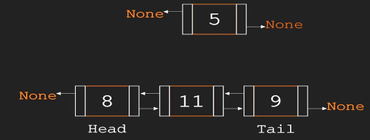

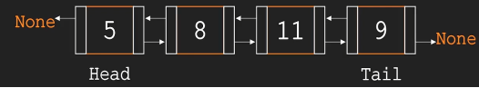

```python
def prepend(self, value): # Defines a method named inside the class. self refers to the current linked list object.
    new_node = Node(value)
    if not self._length: # Checks if the list is empty (_length == 0).
        self.head = self.tail = new_node#If the list is empty,both head & tail point to the new node since its simultaneously the first & last element.
    else : # Runs if the list is not empty.We need to insert the new node before the current head.
        new_node.next = self.head # Links the new node to the existing list.The new node’s next pointer now points to the old head.
        self.head.previous = new_node # The current head (8) now points back to the new node (5) using its previous pointer.
        self.head = new_node # Updates the list’s head to the new node. Now the new node becomes the first element in the list.
    self._length += 1 #  Increases the length counter by 1.
    return self
```

```python
# Lets refresh the existing Class contents
print(my_list.head.value)
print(my_list.tail.value)
print(my_list._length)
```

[output not shown]

```python
# Now when you do "."+tab...you will see prepend function added to SingleLinkListed Class
my_list.prepend(5)
```

[output not shown]

```python
# Now Lets refresh the Class contents again
print(my_list.head.value)
print(my_list.tail.value)
print(my_list._length)
# 5 has replaced head, length has now incremented to 4
```

[output not shown]

#### Time And Space Complexity

When it comes to complexity analysis, I think it's quite simple. We don't have any loops that can increase the number of operations as the list grows. We only have constant time assignments and conditional checks. Also, apart from the new node we're creating, we don't add to memory anything else. So both complexities are a constant O(1). The best possible scenario. And that's it

##### Time : *O* (1)

##### Space : *O* (1)

**Keynotes:**

The function call determines insertion:

```
prepend(value) → Adds before the current head.
append(value) → Adds after the current tail.
```

How does the code know where to insert the node? It depends on whether you're:

```
Prepending (adding at the start) → The new node replaces self.head.
Appending (adding at the end) → The new node replaces self.tail.
```

Each function handles pointer updates differently, ensuring correct placement.

Prepend moves backward (right-to-left connection) since we update head. Append moves forward (left-to-right connection) since we update tail. The code doesn't "choose" a direction—it follows logical pointer assignments based on where the new node is being added!

Before Append Again, assume we start with this: HEAD → [5] ⇄ [8] ⇄ [11] ← TAIL 5 is the head. 11 is the tail. After Appending 15 When you call append(15), here’s the updated list: HEAD → [5] ⇄ [8] ⇄ [11] ⇄ [15] ← TAIL How did the connections change? self.tail.next = new_node → 11.next now points to 15. new_node.previous = self.tail → 15.previous now points back to 11. self.tail = new_node → 15 becomes the new tail. ✅ Left-to-right movement happens naturally because we insert after the current tail! Before Prepend Imagine you have this existing list: HEAD → [8] ⇄ [11] ← TAIL 8 is the head, and its next points to 11. 11 is the tail, and its previous points to 8. 🚀 After Prepending 5 When you call prepend(5), here's what happens: HEAD → [5] ⇄ [8] ⇄ [11] ← TAIL How did the connections change? new_node.next = self.head → 5.next now points to 8. (.next is a forward pointer, that’s why we use new_node.next & not just new_node) self.head.previous = new_node → 8.previous now points back to 5.(.previous is a backward pointer, that’s why we use self.head.previous & not just self.head) self.head = new_node → 5 is now the head of the list. ✅ Right-to-left movement happens naturally because we insert before the current head!